# Binary Response Models

Author

Affiliation

Dave Clark

Binghamton University

Published

August 19, 2026

# Binary $y$ variables

## Questions

- How can we model a binary $y$ variable?
- Does OLS (the **linear probability model**) work sufficiently well?
- How can we build a maximum likelihood model that does work?

## The process

Before we get into the details, here is where we are going. Every limited-$y$ model in this course — binary, count, ordered, duration — is built the same way, following the same short recipe:

**Building a maximum likelihood model**

1. **Observe $y$; consider its distribution; write down its PDF (or PMF).**[^1]
2. **Write the joint probability of the data** under that distribution.
3. **Rewrite the joint probability as a likelihood.**
4. **Simplify** — take logs.
5. **Parameterize** — make the distribution’s parameter a function of covariates, $x\beta$ (the systematic component).
6. **Choose a link function** $F$ that connects $x\beta$ to that parameter and respects its bounds.

That is the whole process - we’ll follow this for much of the semester. The rest of these notes walk through these steps for the binary case: I motivate why we leave OLS behind, build the likelihood step by step, estimate it, and then evaluate the estimates.

# Starting from OLS

In interpretation, nonlinear models like these binary response models are only different from linear models in that we transform the linear prediction by $F$. In OLS, the linear predictor *is* the prediction:

$$\widehat{y} = x\widehat{\beta}$$

When the outcome is binary, the linear predictor $x\beta$ is still meaningful — it’s still a weighted combination of covariates that we can compute for any case. What changes is that we no longer want $x\beta$ itself as the prediction. We want a probability, $Pr(y=1|x)$, bounded on $[0,1]$. So we keep $x\beta$ and add **one more step**: push it through a function that maps it into the probability space.

$$\widehat{y}_{\text{OLS}} = x\widehat{\beta} \qquad\Longrightarrow\qquad \widehat{\pi}_{\text{binary}} = F(x\widehat{\beta})$$

$F$ is the link function. Picking $F$ is the substantive modeling choice — and as we’ll see, that choice has a clean interpretation in terms of the distribution of the latent error. In estimation, the *technologies* are quite distinct from one another; we’ll cover this in the coming couple of weeks. But interpretation is very similar, requiring the same techniques we apply in the linear context, the single difference being that we translate the linear prediction into the appropriate units.

# Why not just estimate OLS? (The LPM)

The main defense of the **linear probability model** is that OLS is unbiased under Gauss-Markov. But:

- predictions are not in the $[0,1]$ interval; unsurprisingly, they’re not probabilities. They’re linear and unbounded; despite the name, the Linear Probability Model does not return probabilities.
- residuals are heteroskedastic and non-normal — this threatens inference.
- the functional form is wrong — the relationship between $x\beta$ and $Pr(y=1)$ should be sigmoid, not linear.

## Example — Democratic Peace data

As a running example we’ll consider the Democratic Peace data from Oneal and Russett (1997) (*ISQ*). The unit is the dyad-year, $y$ is the presence of a militarized dispute, and key covariates include shared border, the lower of the two dyad Polity scores, the capabilities ratio, and an alliance indicator. The substantive expectation: as the minimum democracy score in the dyad rises, the probability of a MID should fall.

### Predictions out of bounds

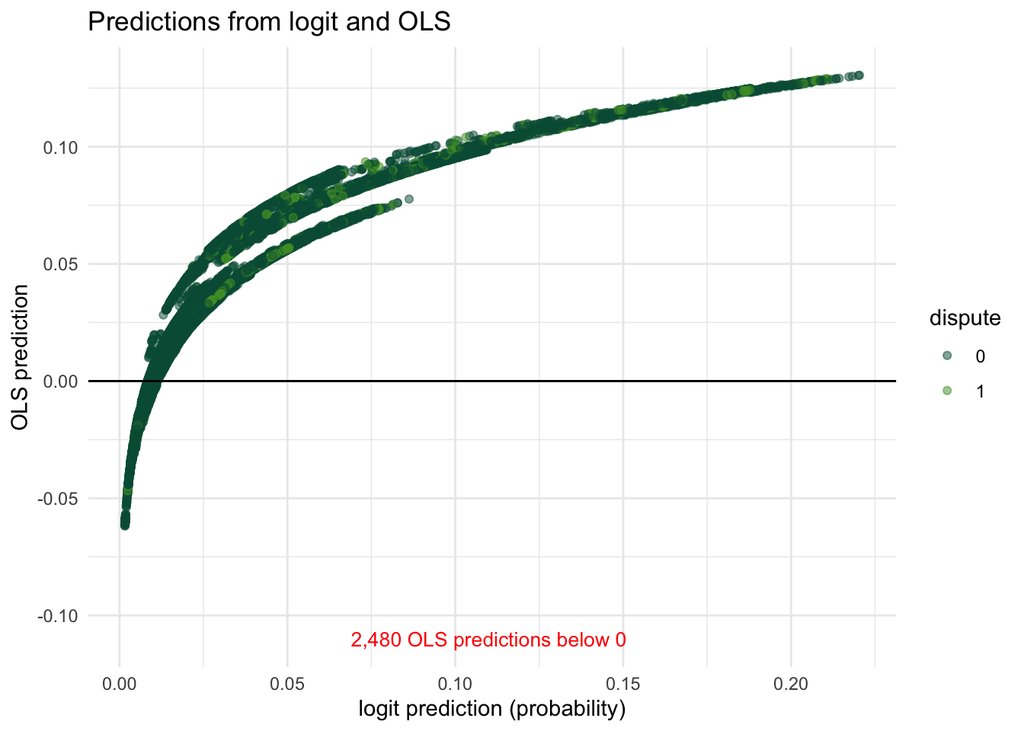

Figure 1

```r
# I fit the two binary models and OLS on the same specification, to compare
# what each one predicts.
m_logit <- glm(dispute ~ border + deml + lncaprat + ally,
               family = binomial(link = "logit"), data = dp)
m_probit <- glm(dispute ~ border + deml + lncaprat + ally,
                family = binomial(link = "probit"), data = dp)
m_ols   <- lm(dispute ~ border + deml + lncaprat + ally, data = dp)

preds <- tibble(
  logit   = predict(m_logit, type = "response"),
  ols     = predict(m_ols),
  dispute = factor(dp$dispute)
)

n_oob <- sum(preds$ols < 0)   # OLS predictions below the probability floor

ggplot(preds, aes(x = logit, y = ols, color = dispute)) +
  geom_point(alpha = 0.5) +
  geom_hline(yintercept = 0) +
  annotate("text", x = 0.11, y = -0.11,
           label = paste(format(n_oob, big.mark = ","), "OLS predictions below 0"),
           color = "red", size = 3.5) +
  scale_color_manual(values = bu_two) +
  labs(title = "Predictions from logit and OLS",
       x = "logit prediction (probability)",
       y = "OLS prediction") +
  theme_minimal()
```

About 12% of the OLS predictions fall below zero. None exceed one here, but only because disputes are rare and the fitted values stay low; with a more common outcome we’d see predictions above one as well. Either way, a number outside $[0,1]$ is not a probability, whatever else it is.

### Heteroskedastic, non-normal residuals

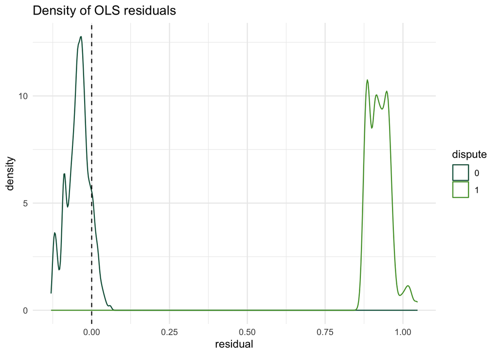

```r
tibble(resid = residuals(m_ols), dispute = factor(dp$dispute)) %>%
  ggplot(aes(x = resid, color = dispute)) +
  geom_density() +
  geom_vline(xintercept = 0, linetype = "dashed") +
  scale_color_manual(values = bu_two) +
  labs(title = "Density of OLS residuals", x = "residual", y = "density") +
  theme_minimal()
```

The residuals bunch around the values that produce $\{0,1\}$ outcomes from a linear fit. In fact the distribution looks more binomial than normal — clustered near zero and one — which shouldn’t surprise us, since $y$ only ever takes the values zero and one and the residuals are just $u = y - \widehat{y}$. So they aren’t going to be normal, and they aren’t going to be homoskedastic.

## So when is the LPM appropriate?

The best answer is *never*.

[figure not shown]

There seems to be a mild trend in the discipline to rehabilitate the LPM, though it’s not clear why — it’s hard to find statements about the advantages of doing so in any particular setting, or about the disadvantages of estimating a logit or probit that would lead us to prefer the LPM.

[figure not shown]

OLS is a rockin’ estimator, but it’s just not well suited to limited $y$ variables. Efforts to rehabilitate the LPM are like putting lipstick on a pig.

# Limited dependent variables

A **limited dependent variable** is one where our measurement is restricted by the world. Binary $y$ is the simplest case — we observe $\{0,1\}$ but believe the underlying quantity is continuous. We are limited to observing $y_i$, and must estimate $y_i^*$.

**Important Concept**

The problem is the data, not OLS. The linear model is simple and powerful. Our data are incomplete realizations of the things we want to study; those limitations push us off the linear model.

## Examples of limited dependent variables

Binary $y$ is just one kind of limited variable. The same logic — build the model around the distribution of what we actually observe — carries through the whole course. A few of the types we’ll meet:

- **binary variables**: 0 = peace, 1 = war; 0 = didn’t vote, 1 = voted.
- **unordered (nominal) categories**: which car you buy — Honda, Toyota, Ford, Buick; vote choice across several candidates; policy options.
- **ordered variables with few values**: many survey responses (disagree / neutral / agree).
- **counts**: the number of militarized disputes a dyad has in a year; episodes of torture in a country-year; arrests; doctor visits — $0, 1, 2, 3, \ldots$
- **time to an event**: how long a civil war lasts; how long a leader survives in office; time until a patient relapses.

Each gets its own distribution and its own link, but the recipe is always the same — which is the whole point of building these models from the distribution up.

## The latent variable motivation

Imagine a latent continuous variable $y^*$ that lives on the real line:

$$y_i^* = x_i\beta + \varepsilon_i$$

We don’t observe $y^*$ directly (if we did, we’d probably be using OLS). We observe a thresholded version of it:

$$y_i = \begin{cases} 1 & \text{if } y_i^* > 0 \\ 0 & \text{if } y_i^* \leq 0 \end{cases}$$

The probability of observing $y_i = 1$ is the probability that $y_i^*$ exceeds the threshold:

$$\begin{aligned}
Pr(y_i = 1 \mid x_i)
&= Pr(y_i^* > 0) && \text{(threshold)} \\
&= Pr(x_i\beta+\varepsilon_i > 0) && \text{(threshold restated)} \\
&= Pr(\varepsilon_i > -x_i\beta) && \text{(isolate the error)} \\
&= 1 - F_\varepsilon(-x_i\beta) && \text{(right tail)} \\
&= F_\varepsilon(x_i\beta) && \text{(symmetry)}
\end{aligned}$$

Take the equalities in turn:

- **(threshold)** — the step to $Pr(y_i^* > 0)$ is the **measurement step**: we record a one exactly when the latent $y_i^*$ clears the threshold, so $Pr(y_i=1)$ just *is* $Pr(y_i^* > 0)$.
- **(isolate the error)** — the step to $Pr(\varepsilon_i > -x_i\beta)$ substitutes $y_i^* = x_i\beta + \varepsilon_i$ and isolates the only random piece, $\varepsilon_i$: given $x_i$, the systematic part $x_i\beta$ is fixed, so a “one” requires the **unobserved** $\varepsilon_i$ to exceed $-x_i\beta$; the observed factors set a bar, and the error has to clear it. This is the substantive line, and the same object a random-utility model produces (see the note below).
- **(right tail)** — the step to $1 - F_\varepsilon(-x_i\beta)$ is where the CDF enters, and with it something we can actually compute. A greater-than probability on $\varepsilon_i$ is an upper tail, and an upper tail is one minus the CDF: $Pr(\varepsilon_i > c) = 1 - F_\varepsilon(c)$, here with $c = -x_i\beta$. Up to now we had an *event* — the error clearing the bar; this rewrites it as a *function* of $x_i\beta$, namely $F_\varepsilon$ itself. That function is the link, and it is what we parameterize and drop into the likelihood to estimate. No $F$, no estimator.
- **(symmetry)** — the step to $F_\varepsilon(x_i\beta)$ uses the **symmetry** of $F_\varepsilon$ about zero such that $1 - F_\varepsilon(-a) = F_\varepsilon(a)$. What it buys is the tidy, estimable form $Pr(y_i=1) = F_\varepsilon(x_i\beta)$: the CDF read at the linear predictor *directly*, increasing in $x_i\beta$ (more of the linear prediction $x_i\beta$, more probability) and evaluated at the same $x_i\beta$ OLS would use. That is the form we parameterize and fit. Both the normal and the logistic are symmetric, so both collapse to it; an asymmetric error (the Gumbel, hence complementary log-log) does not, and keeps the $1 - F_\varepsilon(-x_i\beta)$ shape.

**The random-utility motivation**

The latent variable has a behavioral interpretation you have already encountered in formal theory. Let $y_i^*$ be the **net utility** of one alternative over the other — the utility of option 1 minus the utility of option 0. The labels 0 and 1 are arbitrary: the two options could be two candidates, two commuting modes, two ice cream flavors. Split it the same way: $x_i\beta$ is the **systematic** (representative) utility difference — the part explained by observed characteristics — and $\varepsilon_i$ is the **idiosyncratic** part, the unobserved, agent-specific taste shock. An agent picks option 1 when its net utility is positive, $y_i^* > 0$, which is exactly $\varepsilon_i > -x_i\beta$: the individual taste shock has to be large enough to overcome whatever the observed factors imply. So the middle term of the derivation *is* a choice rule, and the binary model falls straight out of the utility theory — a direct line from the behavioral model to the estimator, rather than a latent variable posited from nowhere.

Two things follow. First, the distribution we assume for $\varepsilon_i$ is a **model of the unobserved utility**: assume those shocks are logistic and we get the logit; assume normal, we get the probit. Choosing the link is choosing how unmodeled tastes are distributed. Second, nothing here needs there to be only two options. Give each alternative $j$ its own utility $U_{ij} = x_i\beta_j + \varepsilon_{ij}$ and let the agent, $i$, choose the one with the highest utility, and the same machinery covers a whole menu of options — candidates in an election, brands on a shelf, foreign policy options. The binary model is just the two-option case of that; we’ll build the general version — several alternatives, McFadden’s derivation, and what the error assumption buys and costs — in the choice model weeks later in the semester.

This is what makes the link function not arbitrary: **$F$ is the CDF of the latent error.** Different assumptions about $\varepsilon$ give different link functions.

- $\varepsilon \sim N(0,1)$ $\longrightarrow$ **probit**, $F = \Phi$
- $\varepsilon \sim \text{Logistic}(0,1)$ $\longrightarrow$ **logit**, $F = \Lambda$
- $\varepsilon \sim \text{Gumbel}$ $\longrightarrow$ **complementary log-log**

Figure 2 illustrates this for a normal (probit) error. Think of the latent variable $y^* = x\beta + \varepsilon$ as a distribution sitting over the real line, centered at $x\beta$, with the threshold fixed at zero; $Pr(y=1)$ is the share of it lying to the right of zero. Raising $x\beta$ slides the whole distribution rightward, so more of it clears the threshold and $Pr(y=1)$ rises; lowering $x\beta$ slides it left. Imagine $x\beta$ at values ranging across the x-axis, and that share accumulates from zero up to one — which is exactly what a CDF does, and why $F$ is one. So the link is no arbitrary sigmoid: **choosing $F$ is choosing a distribution for the error.**[^2]

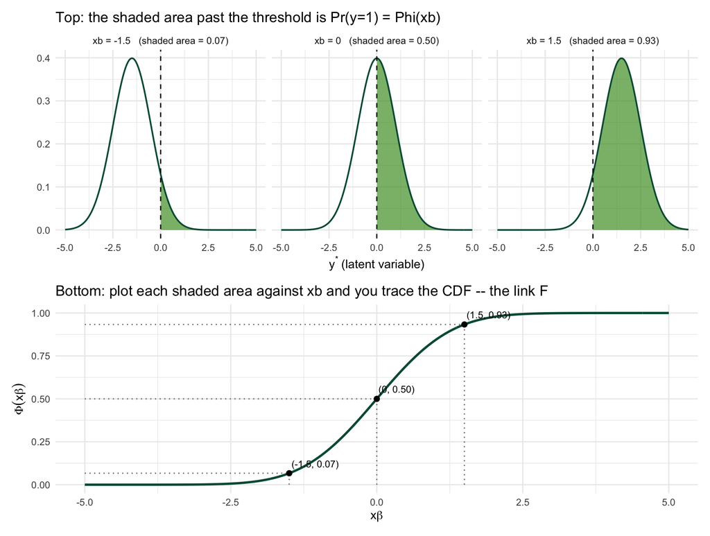

Figure 2

```r
# TOP: the latent bell y* = xb + e ~ N(xb, 1); the shaded area past the fixed
# threshold at 0 is Pr(y=1). That area = 1 - Phi(-xb) = Phi(xb) (standardize --
# the threshold sits -xb SDs from the mean). BOTTOM: plot each shaded area
# against xb and it traces the CDF Phi, so the shaded area up top IS the CDF
# height below. Drawn for a normal error (probit); logit tells the same story.
xb_vals <- c(-1.5, 0, 1.5)
strip   <- sprintf("xb = %g   (shaded area = %.2f)", xb_vals, pnorm(xb_vals))

dens_df <- tibble(xb    = rep(xb_vals, each = 400),
                  ystar = rep(seq(-5, 5, length.out = 400), times = 3)) %>%
  mutate(dens  = dnorm(ystar, mean = xb, sd = 1),
         facet = factor(sprintf("xb = %g   (shaded area = %.2f)", xb, pnorm(xb)),
                        levels = strip))
shaded <- filter(dens_df, ystar > 0)

# Top row: the three bells, shaded area past the threshold = Pr(y=1) = Phi(xb).
p_bells <- ggplot(dens_df, aes(ystar, dens)) +
  geom_area(data = shaded, fill = bu_lightgreen, alpha = 0.7) +
  geom_line(color = bu_green, linewidth = 0.7) +
  geom_vline(xintercept = 0, linetype = "dashed") +           # the fixed threshold
  facet_wrap(~ facet, nrow = 1) +
  labs(title = "Top: the shaded area past the threshold is Pr(y=1) = Phi(xb)",
       x = expression(y^"*"~"(latent variable)"), y = NULL) +
  theme_minimal()

# Bottom row: those areas plotted against xb -- this traces the CDF, the link.
cdf_df <- tibble(xb = seq(-5, 5, length.out = 400), p = pnorm(xb))
marks  <- tibble(xb = xb_vals, p = pnorm(xb_vals))

p_cdf <- ggplot(cdf_df, aes(xb, p)) +
  geom_line(color = bu_green, linewidth = 1) +
  geom_segment(data = marks, aes(x = xb, xend = xb, y = 0, yend = p),
               color = bu_grey, linetype = "dotted") +        # read up from xb
  geom_segment(data = marks, aes(x = -5, xend = xb, y = p, yend = p),
               color = bu_grey, linetype = "dotted") +        # ... across to the height
  geom_point(data = marks, aes(xb, p), color = bu_black, size = 2) +
  geom_text(data = marks, aes(xb, p, label = sprintf("(%g, %.2f)", xb, p)),
            vjust = -0.9, hjust = -0.05, size = 3.1, color = bu_black) +
  labs(title = "Bottom: plot each shaded area against xb and you trace the CDF -- the link F",
       x = expression(x*beta), y = expression(Phi(x*beta))) +
  theme_minimal()

p_bells / p_cdf
```

Look at the two panels together. Each curve’s **shaded area** is a single number — the probability past the threshold — and computing it is one standardization: the bell is $N(x\beta, 1)$, so the threshold at $0$ sits $-x\beta$ standard deviations from the mean, and the area to its right is $1 - \Phi(-x\beta) = \Phi(x\beta)$. That is the whole translation onto the CDF. Take the lefthand bell-curve, $x\beta = -1.5$: the threshold is $1.5$ standard deviations *above* the mean, so only the far tail clears it — about 0.07 of the mass — which is $\Phi(-1.5)$, and that is exactly the **height of the CDF at $x\beta = -1.5$** in the bottom panel. The middle bell splits at the mean (area $0.5$), the right bell clears most of the threshold (about 0.93), and plotting those three areas against $x\beta$ traces the whole sigmoid: the CDF *is* the shaded area, accumulated as $x\beta$ moves. Keep these PDFs in mind because the topic returns in the marginal-effects section below, where we use the PDF’s *height* rather than its area.

Examine the figure a second time through the lens of $Pr(\varepsilon_i > -x_i\beta)$ from the latent variable motivation above: the shaded area *is* that probability — the chance the idiosyncratic $\varepsilon_i$ clears the bar the systematic part sets at $-x_i\beta$. For the lefthand bell, $x_i\beta = -1.5$, so the bar sits at $-x_i\beta = +1.5$: reaching $y=1$ takes a large favorable shock, $\varepsilon_i > 1.5$, which happens only rarely. For the righthand bell, $x_i\beta = +1.5$, so the bar drops to $-x_i\beta = -1.5$: almost any $\varepsilon_i$ clears it, and it is now $y=0$ that would need a large *unfavorable* shock, $\varepsilon_i < -1.5$. Raising $x_i\beta$ slides the bar left — from $+1.5$ toward $-1.5$, asking less and less of the error, the same movement as the shaded area growing from 0.07 to 0.93.

# Building the likelihood

With this background, let’s follow the steps laid out above and build the binary log-likelihood function. We have $y$ and its distribution; next we write the joint probability, turn it into a likelihood, log it, parameterize, and choose a link.

## A nonlinear model for binary data

$y$ is binary, and we’ve established that the linear model is not appropriate. The observed variable $y$ is binomial (iid) — it takes the value 1 with probability $\pi_i$ and 0 with probability $1-\pi_i$:

$$y \sim f_{\text{binomial}}(\pi_i)$$

$$y_i = \begin{cases} 1, & \text{with probability } \pi_i \\ 0, & \text{with probability } 1-\pi_i \end{cases}$$

Two features run through everything below. First, the model has **two parts** — one for the ones and one for the zeros — and they are mirror images of each other: whatever we write for $\pi_i$ when $y=1$, we write for $1-\pi_i$ when $y=0$. Second, **both parts go through the same link function** $F$, which turns the linear predictor $x_i\beta$ into a probability:

$$\pi_i = F(x_i\beta), \qquad 1-\pi_i = 1 - F(x_i\beta)$$

So using the link, $F(x_i\beta)$ is the probability of a one, and $1 - F(x_i\beta)$ is the probability of a zero. Keep that symmetry in mind because this is the shape of every likelihood equation that follows.

## The binomial likelihood

Write the binomial density (the probability of a single observation):

$$Pr(y_i = y \mid \pi_i) = \pi_i^{y_i}(1-\pi_i)^{1-y_i}$$

Read this as the two-part model in one line: when $y_i = 1$ it returns $\pi_i$; when $y_i = 0$ it returns $1-\pi_i$. The exponents are just switches that select the right piece.

Write the joint probability of the data as a likelihood — the product over $n$ iid observations, read as a function of the unknown $\pi$:

$$\mathcal{L}(\pi \mid y) = \prod_{i=1}^{n}\pi_i^{y_i}(1-\pi_i)^{1-y_i}$$

Take the log of that likelihood, which turns the product into a sum:

$$\ln\mathcal{L}(\pi \mid y) = \sum_{i=1}^{n}\left[y_i \ln \pi_i + (1-y_i)\ln(1-\pi_i)\right]$$

We now have a generic and flexible log-likelihood function appropriate for binary response variables.

## Parameterize the model

So far $\pi_i$ is just “the probability of a one.” To make it a *model* — to let covariates shape that probability — we **parameterize** it: we make $\pi_i$ a function of some variables and their slope effects, $x\beta$. This step is worth pausing on, because parameterizing a distribution’s parameter will be a recurring act all semester and may be a new idea. Every distribution we meet has a parameter (here $\pi$ for the binomial; for the Poisson it will be a rate $\lambda$). “Parameterizing” means writing that parameter as a function of covariates — the **systematic component** of the model — so that the data can move the probability around:

$$\pi_i = F(x\beta)$$

Substituting into the log-likelihood gives the binomial log-likelihood function in terms of $\beta$, which is what we actually estimate:

$$\ln\mathcal{L}(\beta \mid y, X) = \sum_{i=1}^{n}\left[y_i \ln F(x_i\beta) + (1-y_i)\ln(1-F(x_i\beta))\right]$$

But we still need to fill in $F$, the link function.

## The link function

We parameterized $\pi_i = F(x\beta)$, and now we need to choose an $F$ that maps the linear prediction onto $\pi_i$ — the probability of a one. The systematic component $x_i\beta$ can range over $[-\infty, +\infty]$, but a probability cannot — so $F$ has to do two things:

- map the whole real line onto $[0,1]$, so our prediction $\widehat{\pi}_i$ is a genuine probability;
- do it smoothly and monotonically — a sigmoid — so more $x\beta$ always means more probability.

Any sigmoid CDF satisfies the bounds; the two we use most commonly are the standard normal (probit) and the logistic (logit). Recall that the CDF we choose for the link also characterizes the distribution of the latent errors per the discussion above.

$$Pr(y_i = 1 \mid X) = \Phi(x_i\beta) \qquad \text{(probit)}$$

$$Pr(y_i = 1 \mid X) = \frac{1}{1 + e^{-x_i\beta}} \qquad \text{(logit)}$$

**Important Concept**

The link function maps the linear prediction onto the sigmoid probability space and obeys the bounds $[0,1]$. Choosing the link is choosing a distribution for the latent error.

This is an important general idea to remember going forward. The link is a **translator** between two number lines, one for $x\beta$ (the linear prediction) and one for $\pi$ (the probability we actually want). Pick a value on the $x\beta$ axis, read up to the curve, read across — that’s $F(x\beta)$. And note what “sliding” means here: the curve itself is fixed and never moves; a change in $x\beta$ just slides the predicted point along it — left for less, right for more. Every predicted probability in the model is from this one curve.

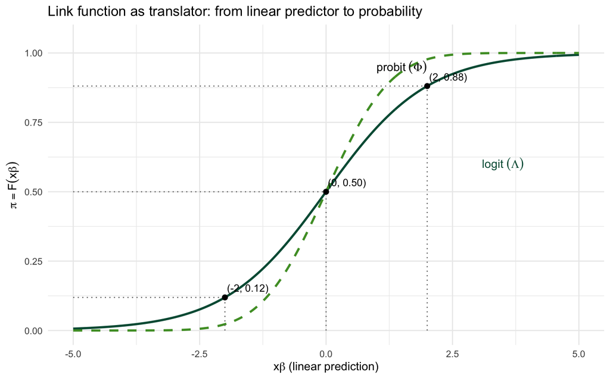

Figure 3

```r
# The two CDFs as translators from the linear predictor to a probability,
# with a few (xb, pi) pairs marked on the logit curve.
xb <- seq(-5, 5, length.out = 400)
curve_df <- tibble(xb = xb, logit = plogis(xb), probit = pnorm(xb))

marks <- tibble(xb = c(-2, 0, 2)) %>% mutate(pi = plogis(xb))

ggplot(curve_df, aes(xb, logit)) +
  geom_line(color = bu_green, linewidth = 1) +
  geom_line(aes(y = probit), color = bu_lightgreen, linewidth = 1, linetype = "dashed") +
  geom_segment(data = marks,
               aes(x = xb, xend = xb, y = 0, yend = pi),
               color = bu_grey, linetype = "dotted") +
  geom_segment(data = marks,
               aes(x = -5, xend = xb, y = pi, yend = pi),
               color = bu_grey, linetype = "dotted") +
  geom_point(data = marks, aes(xb, pi), color = bu_black, size = 2) +
  geom_text(data = marks,
            aes(xb, pi, label = sprintf("(%g, %.2f)", xb, pi)),
            vjust = -0.8, hjust = -0.05, size = 3.4) +
  annotate("text", x = 3.5, y = 0.6, label = "logit~(Lambda)", parse = TRUE, color = bu_green) +
  annotate("text", x = 1.5, y = 0.95, label = "probit~(Phi)", parse = TRUE, color = bu_black) +
  scale_y_continuous(limits = c(0, 1.05)) +
  labs(title = "Link function as translator: from linear predictor to probability",
       x = expression(x*beta~"(linear prediction)"),
       y = expression(pi == F(x*beta))) +
  theme_minimal()
```

**Which link to choose?**

It’s also worth pointing out that in most (nearly all) social science applications, the choice of link function is inconsequential, particularly between logit and probit. As you can see, the differences lie mainly in the tails; logit has fatter tails, so more probability at the extremes. But the differences are small and in empirical settings, mostly unimportant. As we’ll see in a couple of weeks, we can select other link functions that have different properties that may more closely characterize the distribution of $y$ and our expectations about $\varepsilon$.

## Probit and logit log-likelihoods

Filling $F$ into the parameterized log-likelihood gives the model we actually estimate. This is the workhorse log-likelihood, and choosing $F$ fills in the specific model. Writing each one out makes the two-part structure concrete: the link sits inside the $y=1$ term, and one minus the link sits inside the $y=0$ term.

The **probit** uses the standard normal CDF $\Phi$ as the link:

$$\ln\mathcal{L}(\beta \mid y) = \sum_{i=1}^{n}\Big[\, y_i \ln \Phi(x_i\beta) + (1-y_i)\ln\big(1 - \Phi(x_i\beta)\big)\,\Big]$$

The **logit** uses the logistic CDF, $\Lambda(x_i\beta) = \tfrac{1}{1+e^{-x_i\beta}}$:

$$\ln\mathcal{L}(\beta \mid y) = \sum_{i=1}^{n}\left\{\, y_i \ln\!\left(\frac{1}{1+e^{-x_i\beta}}\right) + (1-y_i)\ln\!\left[\,1 - \frac{1}{1+e^{-x_i\beta}}\,\right] \right\}$$

As we did earlier, think of the two terms as the two outcomes, zero and one. The first term is the contribution of the cases where $y=1$ — the probability the model assigns to a one, $F(x_i\beta)$. The second term is the contribution of the cases where $y=0$ — the probability it assigns to a zero, $1 - F(x_i\beta)$. Choosing the link changes what sits inside the parentheses; it does not change that two-part structure. The probit puts $\Phi$ in both slots, the logit puts $\Lambda$ in both slots, and any other binary-response model we write does the same thing with its own $F$.

That is the likelihood. *Maximizing* it — taking its derivatives and climbing to the $\beta$ that makes the observed data most probable — is the topic for the next couple of weeks. For now, we’ll estimate the model and interpret it.

# Estimation

```r
modelsummary(
  list("Logit" = m_logit, "Probit" = m_probit),
  coef_rename = c("border" = "Shared border",
                  "deml"   = "Min. democracy",
                  "lncaprat" = "Capabilities ratio (log)",
                  "ally"   = "Allied"),
  statistic = "std.error",
  gof_omit  = "AIC|BIC|RMSE|F|Log",
  notes     = "Standard errors in parentheses."
)
```

|  | Logit | Probit |
| --- | --- | --- |
| (Intercept) | -2.987 | -1.653 |
|  | (0.107) | (0.048) |
| Shared border | 1.036 | 0.491 |
|  | (0.088) | (0.041) |
| Min. democracy | -0.070 | -0.031 |
|  | (0.007) | (0.003) |
| Capabilities ratio (log) | -0.227 | -0.101 |
|  | (0.024) | (0.011) |
| Allied | -0.842 | -0.371 |
|  | (0.081) | (0.038) |
| Num.Obs. | 20990 | 20990 |

Standard errors in parentheses.

# Interpretation

A logit or probit coefficient is not, by itself, a substantive claim — it lives on the scale of the linear predictor (the log-odds for logit, a $z$-score for probit), not on the probability scale we actually care about. Three important interpretive pieces for every binary model:

1. **Signs and significance** — all the usual rules apply, but the coefficient itself is not the substantive quantity.
2. **Quantities of interest** — almost always either $Pr(y=1\mid X)$ at meaningful $X$ values, or the marginal effect $\partial Pr(y=1)/\partial x_k$.
3. **Uncertainty** — confidence intervals (or simulation-based intervals) on the quantities of interest, not just on $\beta$.

As mentioned previously, we’ve covered different prediction methods and approaches for estimating standard errors for predictions in the linear model - those all apply in the non-linear case. While we’ll spend a little time reviewing those, you should be quite familiar with them by this point. Below, let’s generate at-mean predictions based on the model we estimated.

## Predicted probabilities

Predicted probabilities are the most commonly reported quantities of interest for binary response models. For the logit, the predicted probability is[^3]

$$\widehat{Pr}(y=1\mid X) = \frac{1}{1+e^{-x\widehat\beta}},$$

and for the probit the probability $y=1$ is:

$$\widehat{Pr}(y=1\mid X) = \Phi(x\widehat\beta).$$

In both cases we are doing the same thing — transforming the linear prediction $x\widehat\beta$ through the link function so it maps onto the $[0,1]$ probability space.

The figure below does this for democracy. These are **at-means** (adjusted) predictions — democracy varies across its range while the other covariates are held at representative values (the mode for the binary covariates, the median for the skewed capability ratio). We’ll revisit prediction methods specifically in the context of nonlinear models in the coming weeks.

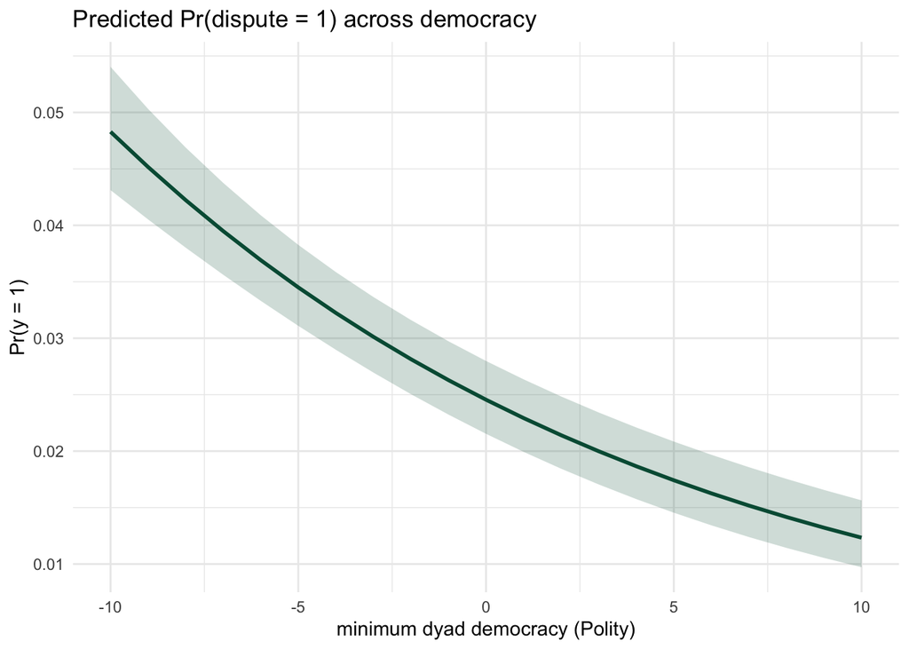

```r
# At-means (adjusted) predictions: democracy varies across its range; the other
# x-variables are held at representative values -- the mode for the binary
# covariates (border, ally), the median for skewed capability ratio.
# (datagrid's default would hold numerics at their mean; I set them
# to the mode/median to address skewness)
modal <- function(x) as.numeric(names(which.max(table(x)))) #function to find mode - R lacks such a function

preds_dem <- predictions(
  m_logit,
  newdata = datagrid(deml   = seq(-10, 10, length.out = 21), #functions from "marginaleffects" library to generate data for predictions
                     border = modal(dp$border),
                     ally   = modal(dp$ally),
                     lncaprat = median(dp$lncaprat, na.rm = TRUE))
)

ggplot(preds_dem, aes(deml, estimate)) +
  geom_ribbon(aes(ymin = conf.low, ymax = conf.high),
              fill = bu_green, alpha = 0.2) +
  geom_line(color = bu_green, linewidth = 1) +
  labs(title = "Predicted Pr(dispute = 1) across democracy",
       x = "minimum dyad democracy (Polity)",
       y = "Pr(y = 1)") +
  theme_minimal()
```

The prediction plot indicates that for a non-bordering, non-allied dyad at median capabilities, the probability of a militarized dispute is about 0.048 when the two states are maximally autocratic (minimum democracy $=-10$), and about 0.012 when they are maximally democratic ($=+10$). So moving a dyad from fully autocratic to fully democratic cuts its predicted chance of a dispute to roughly a quarter of what it was.

## Marginal effects

Start with the linear model, where this is easy and familiar. The marginal effect of $x_k$ — the change in $\widehat y$ for a one-unit change in $x_k$ — is just $\widehat\beta_k$:

$$\frac{\partial \widehat y}{\partial x_k} = \frac{\partial\, x\widehat\beta}{\partial x_k} = \widehat\beta_k.$$

It is **constant** — the same at every value of $x$.

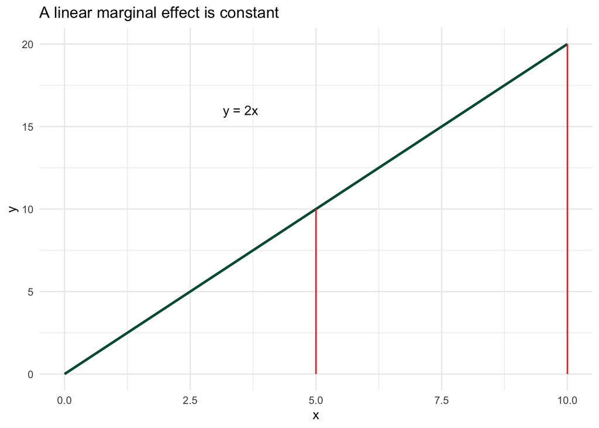

```r
me_line <- tibble(x = seq(0, 10, 0.1), y = 2 * x)

ggplot(me_line, aes(x, y)) +
  geom_line(color = bu_green, linewidth = 1) +
  annotate("segment", x = 5,  xend = 5,  y = 0, yend = 10, color = "red") +
  annotate("segment", x = 10, xend = 10, y = 0, yend = 20, color = "red") +
  annotate("text", x = 3.5, y = 16, label = "y = 2x") +
  labs(title = "A linear marginal effect is constant", x = "x", y = "y") +
  theme_minimal()
```

The effect of $x$ on $y$ here is 2 — the same at $x=5$ as at $x=10$. The nonlinear model breaks that. Because the prediction runs through the curve $F$, the marginal effect depends on *where on the curve* we are — that is, on where $x\widehat\beta$ sits with respect to that curve:

$$\frac{\partial Pr(y=1)}{\partial x_k} = \frac{\partial F(x\beta)}{\partial x\beta}\cdot\frac{\partial x\beta}{\partial x_k} = f(x\beta)\,\widehat{\beta}_k,$$

where the derivative of the CDF $F$ is its PDF $f$. So the marginal effect is $\widehat\beta_k$ **weighted by the height of the PDF** at $x\widehat\beta$ — large where the density is tall, small where it is flat.

**Important Concept**

The effect of $x$ on $Pr(y=1)$ is not constant. It is largest where the latent PDF is densest — for probit and logit, that’s near $x\beta=0$, i.e., where $Pr(y=1) \approx 0.5$. Near the floor (0) or ceiling (1), the same $\widehat{\beta}$ moves the probability hardly at all.

Take a look at the next figure — it shows the logit CDF with tangent line slopes at three different points. The link function is a single fixed sigmoid; the marginal effect at any point is its **slope** there. In the middle, the curve is steep, so a change in $x\beta$ moves the probability a lot; out in the tails it is nearly flat, so the same change barely moves it. Where a given case sits on the curve is set by its own values of the $x$ variables — as they increase, it slides right toward the steep middle; as they decrease, it slides left into the flat tail. That is why one coefficient can deliver a large effect for one case and a tiny one for another: same $\widehat\beta$, different place on the curve.

**Two important asides on marginal effects**

First, note the symmetry of the CDF (true for logistic and normal) — the slopes in the tails are the same even though the values of $x\beta$ would be different from one another, as would the predicted probabilities. It is also the case that the maximum slope in the middle at zero (0.25) is the maximum height of the logit PDF — we’ll see the two side by side shortly. This implies that the maximum marginal effect of any $x_k$ variable in a logit model is $0.25\,\widehat\beta_k$. You’ll see this illustrated below.

Second, as indicated above, a change in any $x_k$ will shift the prediction on the CDF. Changing the value of a control variable will change the predicted probability *even if the variable of interest stays the same*. In a couple of weeks, we’ll return to this — the **inherent interactivity** of nonlinear models, which Nagler describes as being “‘interactive’ in all of their variables” and inherent to the specification (Nagler 1994, 1991; Ai and Norton 2003; Berry, DeMeritt, and Esarey 2010).

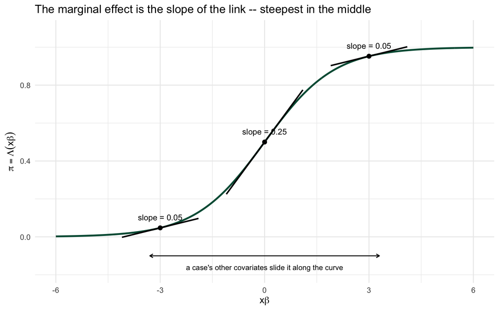

Figure 4

```r
# The marginal effect of a covariate is the SLOPE of the link at the point where
# a case sits. For the logit that slope is the density lambda(xb), which works out
# to Lambda(xb)*(1-Lambda(xb)) = Pr(1)*Pr(0) (derived in "Logit marginal effects"
# below):
# tallest in the middle (0.25 at xb = 0, where Pr = .5), flat in the tails. A
# case's other covariates set WHERE on the curve it sits -- raise them and it
# slides toward the steep middle, lower them and it slides into the flat tail.
# Same coefficient, different effect.
sig <- tibble(xb = seq(-6, 6, length.out = 400), p = plogis(xb))

pts <- tibble(xb = c(-3, 0, 3)) %>%          # three positions on the curve
  mutate(p = plogis(xb), slope = p * (1 - p))

d <- 1.1                                      # half-length of each tangent, in xb units
tangents <- pts %>%
  mutate(x0 = xb - d, x1 = xb + d,
         y0 = p - slope * d, y1 = p + slope * d)

ggplot(sig, aes(xb, p)) +
  geom_line(color = bu_green, linewidth = 1) +
  geom_segment(data = tangents, aes(x = x0, xend = x1, y = y0, yend = y1),
               color = bu_black, linewidth = 0.8) +
  geom_point(data = pts, aes(xb, p), color = bu_black, size = 2) +
  geom_text(data = pts, aes(xb, p, label = sprintf("slope = %.2f", slope)),
            vjust = -1.3, size = 3.3) +
  annotate("segment", x = -3.3, xend = 3.3, y = -0.10, yend = -0.10,
           arrow = arrow(length = unit(0.15, "cm"), ends = "both"), color = bu_black) +
  annotate("text", x = 0, y = -0.16, size = 3, color = bu_black,
           label = "a case's other covariates slide it along the curve") +
  scale_y_continuous(limits = c(-0.18, 1.08)) +
  labs(title = "The marginal effect is the slope of the link -- steepest in the middle",
       x = expression(x*beta), y = expression(pi == Lambda(x*beta))) +
  theme_minimal()
```

For the democratic-peace data this is why the average marginal effects below are quite small: disputes are rare, so most dyads sit far out on the flat lefthand tail, where even a relatively large coefficient moves the probability only a little.

### Logit marginal effects

For the logit, the PDF $\lambda$ has a particularly clean form. Working it through:

$$\begin{aligned}
\frac{\partial \Lambda(x\beta)}{\partial x_k}
&= \lambda(x\beta)\,\widehat\beta_k \\
&= \frac{e^{x\beta}}{(1+e^{x\beta})^2}\,\widehat\beta_k \\
&= \frac{e^{x\beta}}{1+e^{x\beta}}\cdot\frac{1}{1+e^{x\beta}}\,\widehat\beta_k \\
&= \Lambda(x\beta)\big(1-\Lambda(x\beta)\big)\,\widehat\beta_k.
\end{aligned}$$

Looking at the last line above, the marginal effect is the **probability of a one** times the **probability of a zero** times $\widehat\beta_k$. That product $\Lambda(1-\Lambda)$ is largest when $\Lambda = 0.5$, where it is $0.5\times0.5 = 0.25$. So the largest marginal effect any covariate can have in a logit is $0.25\,\widehat\beta_k$.

In the democratic-peace model, the coefficient on democracy is about -0.07. So the largest effect a one-unit change in democracy can have on the probability of a dispute is one-quarter of that — about -0.0175 — and that only near $Pr(y=1)=0.5$, which for these rare-event data almost never happens.

### Probit marginal effects

The probit works the same way, with the standard normal PDF $\phi$ in place of $\lambda$:

$$\frac{\partial \Phi(x\beta)}{\partial x_k} = \phi(x\beta)\,\widehat\beta_k.$$

The standard normal density peaks at $x\beta = 0$, where $\phi(0) = \tfrac{1}{\sqrt{2\pi}} \approx 0.4$. So the maximum marginal effect of any covariate in a probit is about $0.4\,\widehat\beta_k$.

Put the two link functions side by side to see where $0.25$ and $0.4$ come from — and to tie the marginal effect back to the density we started with.

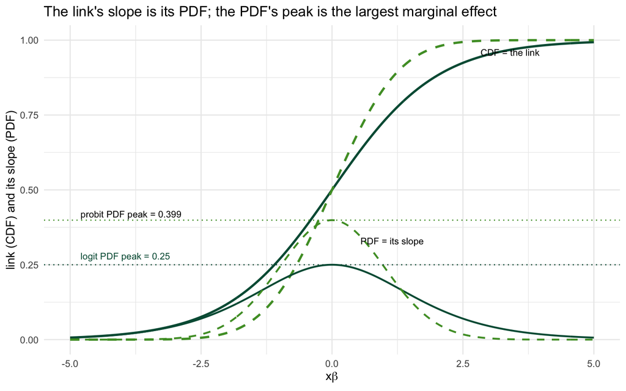

Figure 5

```r
# Each link's PDF is the slope of its CDF, and the PDF's peak (at xb = 0) is the
# largest marginal-effect weight: 0.25 for the logit, 0.399 for the probit.
# Colors match fig-mapping: logit = green (solid), probit = light green (dashed).
z    <- seq(-5, 5, length.out = 400)
dens <- tibble(z = z,
               logit_cdf  = plogis(z), logit_pdf  = dlogis(z),
               probit_cdf = pnorm(z),  probit_pdf = dnorm(z))

ggplot(dens, aes(z)) +
  geom_line(aes(y = logit_cdf),  color = bu_green,      linewidth = 1) +
  geom_line(aes(y = probit_cdf), color = bu_lightgreen, linewidth = 1, linetype = "dashed") +
  geom_line(aes(y = logit_pdf),  color = bu_green,      linewidth = 0.8) +
  geom_line(aes(y = probit_pdf), color = bu_lightgreen, linewidth = 0.8, linetype = "dashed") +
  geom_hline(yintercept = 0.25,   color = bu_green,      linetype = "dotted") +
  geom_hline(yintercept = 0.3989, color = bu_lightgreen, linetype = "dotted") +
  annotate("text", x = -4.8, y = 0.28, hjust = 0, size = 3, color = bu_green,
           label = "logit PDF peak = 0.25") +
  annotate("text", x = -4.8, y = 0.42, hjust = 0, size = 3, color = bu_black,
           label = "probit PDF peak = 0.399") +
  annotate("text", x = 3.4,  y = 0.96, size = 3, color = bu_black, label = "CDF = the link") +
  annotate("text", x = 1.15, y = 0.33, size = 3, color = bu_black, label = "PDF = its slope") +
  labs(title = "The link's slope is its PDF; the PDF's peak is the largest marginal effect",
       x = expression(x*beta), y = "link (CDF) and its slope (PDF)") +
  theme_minimal()
```

The PDF under each S-curve is its slope — the density $f$ — the very weight from Figure 4, now shown for both links. Its peak sits at $x\beta = 0$: $0.25$ for the logit, $0.399$ for the probit. And for the probit the plot is the normal bell curve from Figure 2, whose *area* past the threshold gave us $Pr(y=1)$. There we read the model off the density’s area; here we read the marginal effect off its height. Same density, two jobs.

In practice we rarely report the maximum; we report the **average marginal effect** — the effect computed for each case in the sample and averaged across all of them. That’s a quantity-of-interest method we develop fully later, but here is the average marginal effect for the logit:

```r
ames <- avg_slopes(m_logit)

ames %>%
  as_tibble() %>%
  dplyr::select(term, estimate, std.error, conf.low, conf.high) %>%
  knitr::kable(digits = 3, caption = "Average marginal effects, logit")
```

Average marginal effects, logit

| term | estimate | std.error | conf.low | conf.high |
| --- | --- | --- | --- | --- |
| ally | -0.032 | 0.003 | -0.038 | -0.027 |
| border | 0.046 | 0.004 | 0.037 | 0.055 |
| deml | -0.003 | 0.000 | -0.003 | -0.002 |
| lncaprat | -0.009 | 0.001 | -0.011 | -0.007 |

Looking at these effects, we can say the average marginal effect of the minimum democracy score is about -0.0029: averaging over every dyad in the sample, raising the lower democracy score by one point lowers the predicted probability of a militarized dispute by about that much — roughly three in a thousand. It is small for the reason the callout gave: disputes are rare, so these data sit far out on the flat tail of the logistic curve, where even a genuine effect moves the probability only a little. Shared border, by contrast, carries the largest average marginal effect in the model, about 0.046 — contiguity raises the average predicted probability of a dispute by four or five percentage points.

## Logit odds and log-odds

The logit has one more interpretation that the probit lacks, and it can be a useful one. The **odds** of an event are the probability it happens over the probability it doesn’t:

$$\Omega(X) = \frac{Pr(y=1)}{1-Pr(y=1)} = \frac{\Lambda(X\beta)}{1-\Lambda(X\beta)}.$$

Take logs, and the **log-odds turn out to be exactly linear in $X$**:

$$\ln\Omega(X) = X\beta,$$

so $\partial \ln\Omega / \partial x_k = \widehat\beta_k$, constant. This is why a logit coefficient is sometimes just called “the logit” — it *is* the change in the log-odds for a one-unit change in $x_k$.

To read a coefficient on this scale, take it at face value. The coefficient on shared border is about 1.04, so moving `border` from 0 to 1 *adds* about 1.04 to the log-odds of a dispute — and it adds the same amount whatever the other covariates are. Democracy’s coefficient is about -0.07; being negative, each one-point rise in the minimum democracy score *subtracts* about 0.07 from the log-odds. Additive and constant — that is the appeal of the log-odds scale. The catch is that no one has much intuition for a log-odds, which is why we usually exponentiate back to odds.

### Odds ratios

Log-odds are linear but not very intuitive. Exponentiating gets us back to odds, and the ratio of the odds at $x_k+1$ versus at $x_k$ is simply

$$\frac{\Omega(x_k+1)}{\Omega(x_k)} = e^{\widehat\beta_k}.$$

The change need not be one unit; for a change of $\delta$ it’s $e^{\widehat\beta_k \delta}$. Most usefully,

$$100\cdot(e^{\widehat\beta_k}-1)$$

is the **percentage change in the odds** for a one-unit change in $x_k$ — a summary that doesn’t depend on the values of the other $X$ variables.

For example, the logit coefficient on shared border is about 1.04. Exponentiating that coefficient gives roughly 2.82 — so sharing a border multiplies the odds of a dispute by about that factor, a 182% increase in the odds.

Democracy runs the other way. Its coefficient is about -0.07, so exponentiating gives about 0.932 — each one-point rise in the lower democracy score multiplies the odds of a dispute by that factor, a -7% change. The minus sign carries straight through to the odds: more democracy, lower odds of conflict.

# Where this goes next

We’ve built the binary model from its distribution up, fit it, and interpreted it three ways — predicted probabilities, marginal effects, and odds. Two things we’ve deliberately set aside:

- **Mechanics of MLE** - we know how OLS generates estimates. We need to establish how the technology of maximum likelihood takes the data matrix and produces estimates of coefficients.
- **Diagnostics and fit** — separation, classification and ROC, the test trinity, influential cases, and rare-event corrections — get their own treatment in the binary extensions notes, where they belong.

Back to top

## References

Ai, Chunrong, and Edward C. Norton. 2003. “Interaction Terms in Logit and Probit Models.” *Economics Letters* 80 (1): 123–29. https://doi.org/10.1016/S0165-1765(03)00032-6.

Berry, William D., Jacqueline H. R. DeMeritt, and Justin Esarey. 2010. “Testing for Interaction in Binary Logit and Probit Models: Is a Product Term Essential?” *American Journal of Political Science* 54 (1): 248–66.

Nagler, Jonathan. 1991. “The Effect of Registration Laws and Education on U.S. Voter Turnout.” *American Political Science Review* 85 (4): 1393–1405. https://doi.org/10.2307/1963952.

———. 1994. “Scobit: An Alternative Estimator to Logit and Probit.” *American Journal of Political Science* 38 (1): 230–55.

Oneal, John R., and Bruce M. Russett. 1997. “The Classic Liberals Were Right: Democracy, Interdependence, and Conflict, 1950-1985.” *International Studies Quarterly* 41 (2): 267–94.

## Footnotes

[^1]: A **probability mass function** puts a probability on each value a discrete variable can take: each value has some assigned probability, and these probabilities sum to one. A **probability density function** describes a continuous variable, where any single value has probability zero — there are uncountably many of them, so none can carry positive probability. The density $f(x)$ is not a probability but a *rate* (probability per unit of $x$); you get an actual probability only by integrating it over a range — the area under the curve between two points. Hence *mass at a point*, *density over an interval*.
[^2]: I used Claude Code to generate Figures 2 and 4 in these slides.
[^3]: The logit probability is just as often written as $\Lambda(x\beta) = \frac{e^{x\beta}}{1+e^{x\beta}}$, but it’s the same function. To see how, multiply the top and bottom of $\frac{1}{1+e^{-x\beta}}$ by $e^{x\beta}$: the top becomes $e^{x\beta}$, and the bottom becomes $e^{x\beta}\left(1+e^{-x\beta}\right) = e^{x\beta}+1$, since $e^{x\beta}e^{-x\beta}=e^{0}=1$. So $\dfrac{1}{1+e^{-x\beta}} = \dfrac{e^{x\beta}}{1+e^{x\beta}}$.